# Illustrate sensor aliasing

Problems arise when a lens renders a very fine pattern that exceeds the Nyquist sampling rate of the sensor. In that case the sensor outputs will be incorrectly interpreted, usually as a relatively coarse pattern. The apparently coarse pattern is called an alias: it appears to be vary slowly across space even though the original image varies rapidly.

## Contents

[figure not shown]

[figure not shown]

[figure not shown]

To prevent aliasing, we choose lenses that do not pass high frequency patterns that exceed the Nyquist sampling rate of the sensor. This was common in the early days of digital imaging, and manufacturers often included a special blurring filter that would prevent aliasing.

When the sensor sampling rate is very high, say high enough rate to sample even a diffraction-limited lens, there is no need to use an anti-aliasing filter. That is the direction that the industry now has taken.

**See also:** hwSensorAliasing, s_sensorAliasing

```matlab
ieInit
```

## Set up a high frequency harmonic

```matlab
fov = 1;
hParams = harmonicP;
hParams.freq = 8;
hParams.row = 128; hParams.col = 256;
scene = sceneCreate('harmonic',hParams);
scene = sceneSet(scene,'fov',fov);
sceneWindow(scene);

% Set up a high quality lens
oi = oiCreate('diffraction limited');
oi = oiSet(oi,'optics fnumber', 2);
oi = oiCompute(oi,scene);
oiWindow(oi);
```

[figure not shown]

## We use a small (1 ) pixel

[figure not shown]

[figure not shown]

[figure not shown]

```matlab
sensor = sensorCreate('monochrome');
sensor = sensorSetSizeToFOV(sensor,3*fov,oi);

sensor = sensorSet(sensor,'pixel size constant fill factor',1e-6);
sensor = sensorCompute(sensor,oi);
sensorWindow(sensor);

% Plot a middle row
middleRow = round(sensorGet(sensor,'row')/2);
sensorPlot(sensor,'electrons hline',[1 middleRow]);
```

## Use a bigger pixel (6 )

[figure not shown]

The aliased signal is plotted on the right. The scene and oi are high spatial frequency, but the sensor data appears to correspond to a low spatial frequency.

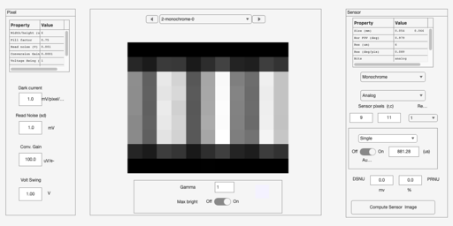

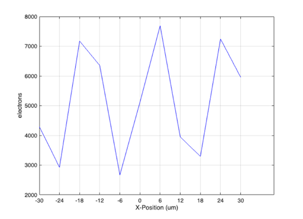

```matlab
sensor = sensorSet(sensor,'pixel size constant fill factor',6e-6);
sensor = sensorSetSizeToFOV(sensor,fov,oi);
sensor = sensorCompute(sensor,oi);
sensorWindow(sensor);

middleRow = round(sensorGet(sensor,'row')/2);
sensorPlot(sensor,'electrons hline',[1 middleRow]);
```

## Now, reduce aliasing by using a blurry lens

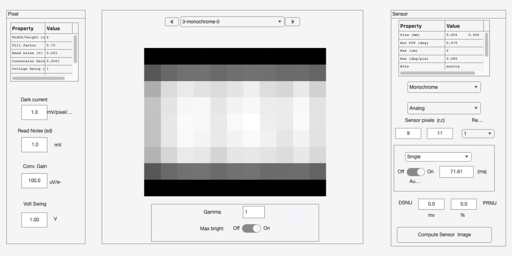

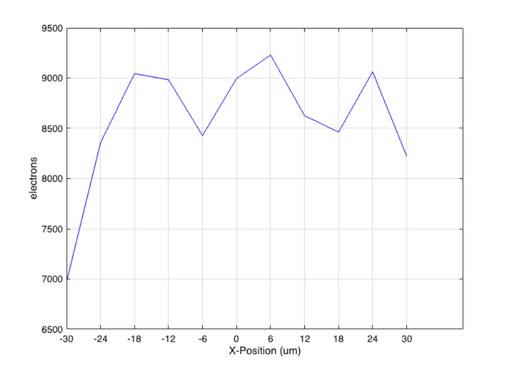

```matlab
oi = oiSet(oi,'optics fnumber', 14);
oi = oiCompute(oi,scene);
sensor = sensorCompute(sensor,oi);
sensorWindow(sensor);

middleRow = round(sensorGet(sensor,'row')/2);
sensorPlot(sensor,'electrons hline',[1 middleRow]);
```

## Video: the aliasing transition as pixel size increases

Hold the scene and optics fixed while increasing pixel size. Each sensor image is interpolated onto a common grid so the sequence can be encoded as a movie even though the physical sensor dimensions change.

```matlab
oi = oiSet(oi,'optics fnumber',2);
oi = oiCompute(oi,scene);
pixelSizes = linspace(1e-6,8e-6,24);
movieRows = 128;
movieCols = 256;
aliasingFrames = zeros(movieRows,movieCols,numel(pixelSizes));

for ii = 1:numel(pixelSizes)
    sensor = sensorSet(sensor,'pixel size constant fill factor',pixelSizes(ii));
    sensor = sensorSetSizeToFOV(sensor,fov,oi);
    sensor = sensorCompute(sensor,oi);

    electrons = sensorGet(sensor,'electrons');
    sourceRows = linspace(1,size(electrons,1),movieRows);
    sourceCols = linspace(1,size(electrons,2),movieCols);
    [sourceColGrid,sourceRowGrid] = meshgrid(sourceCols,sourceRows);
    aliasingFrames(:,:,ii) = interp2(electrons,sourceColGrid,sourceRowGrid,'linear');
end

movieFile = fullfile(fileparts(mfilename('fullpath')),'video_sensorAliasing.mp4');
ieMovie(aliasingFrames,'vname',movieFile,'show',false,'FrameRate',8);
```

[video not shown]

## Let's use a different pattern

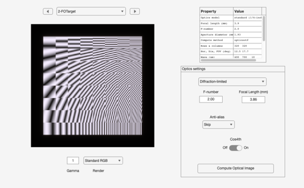

```matlab
scene = sceneCreate('freqorient',[512 512]);
oi = oiSet(oi,'optics fnumber', 2);
oi = oiCompute(oi,scene);
oiWindow(oi);
```

## Adding the impact of a color filter array (1 )

[figure not shown]

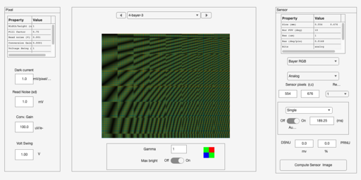

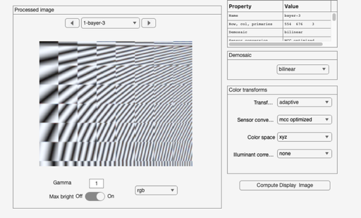

```matlab
sensor = sensorCreate;
sensor = sensorSet(sensor,'pixel size constant fill factor',1e-6);
sensor = sensorSetSizeToFOV(sensor,sceneGet(scene,'fov'),oi);
sensor = sensorCompute(sensor,oi);
sensorWindow(sensor);

ip = ipCreate; ip = ipCompute(ip,sensor);
ipWindow(ip);
```

## A CFA with 6 $um$pixels

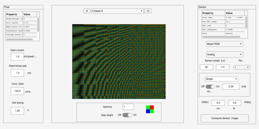

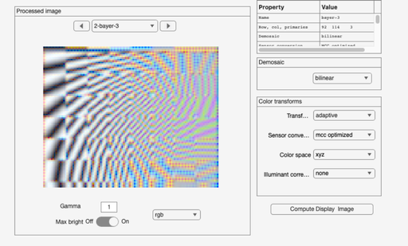

```matlab
sensor = sensorSet(sensor,'pixel size constant fill factor',6e-6);
sensor = sensorSetSizeToFOV(sensor,sceneGet(scene,'fov'),oi);
sensor = sensorCompute(sensor,oi);
sensorWindow(sensor);

ip = ipCreate; ip = ipCompute(ip,sensor);
ipWindow(ip);
```

[Published with MATLAB® R2025b](https://www.mathworks.com/products/matlab/)